# Informe Acerca del consumo del café en estudiantes UTEC durante el ciclo 2024 - 2

Authors

Miguel Edison Alania Huillca

Rodrigo Andrés Tassara Acosta

Fabricio Alberto Olagibel Romero

Isaac Eduardo Trinidad Leiva

Hector Emilio Huaman Puiquin (Lider)

```r
instalar_si_no_existe <- function(paquete) {
  if (!require(paquete, character.only = TRUE)) {
    install.packages(paquete, dependencies = TRUE)
  }
  suppressPackageStartupMessages(invisible(library(paquete, character.only = TRUE)))
}

librerias <- c("readr", "plyr", "dplyr", "tidyr", "tidyverse", "ggplot2", "lubridate", "ggalt", "scales")

suppressMessages(invisible(lapply(librerias, instalar_si_no_existe)))

if (!require("conflicted")) {
  install.packages("conflicted")
}
suppressPackageStartupMessages(invisible(library(conflicted)))

invisible(conflict_prefer("arrange", "dplyr", quiet = TRUE))
invisible(conflict_prefer("count", "dplyr", quiet = TRUE))
invisible(conflict_prefer("desc", "dplyr", quiet = TRUE))
invisible(conflict_prefer("failwith", "plyr", quiet = TRUE))
invisible(conflict_prefer("filter", "dplyr", quiet = TRUE))
invisible(conflict_prefer("id", "plyr", quiet = TRUE))
invisible(conflict_prefer("lag", "dplyr", quiet = TRUE))
invisible(conflict_prefer("mutate", "dplyr", quiet = TRUE))
invisible(conflict_prefer("rename", "dplyr", quiet = TRUE))
invisible(conflict_prefer("summarise", "dplyr", quiet = TRUE))
invisible(conflict_prefer("summarize", "dplyr", quiet = TRUE))
```

# I. Introducción

## 1. Relevancia

El café es una de las bebidas más populares del mundo. En el ámbito académico, especialmente entre los estudiantes universitarios, el consumo de café se ha vuelto casi indispensable, pues muchos lo utilizan durante las largas jornadas de estudio y mantener la concentración. Sin embargo, el impacto real de esta bebida en el rendimiento académico sigue siendo un tema de debate.

Este informe tiene como objetivo investigar el consumo de café entre los estudiantes de la Universidad de Ingeniería y Tecnología durante 2024-2. A través de encuestas y análisis de datos, se evaluará no sólo la frecuencia y cantidad de café consumido, sino también su relación con factores como el rendimiento académico, y el bienestar financiero de los estudiantes. La intención es brindar una conclusión imparcial sobre los resultados de la investigación respecto a los objetivos escogidos.

## 2. Planificación

Se elaboro un diagrama donde se muestra como fue el proceso del desarrollo del proyecto:

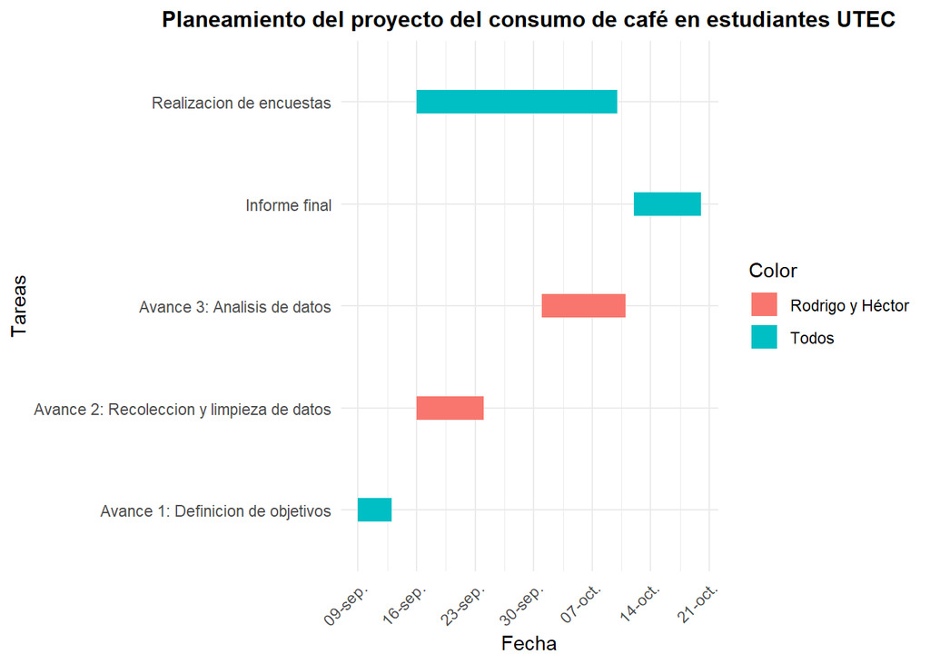

```r
data <- data.frame(
  Task = c("Avance 1: Definicion de objetivos",
           "Avance 2: Recoleccion y limpieza de datos",
           "Realizacion de encuestas",
           "Avance 3: Analisis de datos",
           "Informe final"),

  Start = as.Date(c("2024-09-09", "2024-09-16", "2024-09-16", "2024-10-01", "2024-10-12")), # Fechas de inicio
  End = as.Date(c("2024-09-13", "2024-09-24", "2024-10-10", "2024-10-11", "2024-10-20")),   # Fechas de fin

  Responsable = c("Todos",
                  "Rodrigo y Héctor",
                  "Todos",
                  "Rodrigo y Héctor",
                  "Todos")
)

data$Color <- factor(data$Responsable, levels = c("Rodrigo y Héctor", "Todos"))

ggplot(data, aes(x = Start, xend = End, y = Task, yend = Task, color = Color)) +
  geom_segment(linewidth = 6) +
  scale_x_date(breaks = date_breaks("1 week"), labels = date_format("%d-%b")) +
  labs(title = "Planeamiento del proyecto del consumo de café en estudiantes UTEC",
       x = "Fecha",
       y = "Tareas") +
  theme_minimal() +
  theme(
    axis.text.x = element_text(angle = 45, hjust = 1),
    plot.title = element_text(hjust = +0.5, face = "bold", size = 12)
  )
```

## 3. Objetivos

Este proyecto cuenta con un objetivo general (el cual fue acordado por la sección 4.01) y 2 objetivos específicos, los cuales fueron decididos por nuestro grupo.

### 3.1 Objetivo general

**Determinar si en su mayoría los alumnos de pre-grado de la Universidad de Ingeniería y Tecnología consumen café.**

### 3.2 Objetivos específicos

**1. Explorar la relación entre el consumo de café y el rendimiento académico en los estudiantes de pre-grado de la Universidad de Ingeniería y Tecnología.**

**2. Explorar la relación económica entre el consumo de café y los estudiantes de pre-grado de la Universidad de Ingeniería y Tecnología.**

# II. Datos

## 1. Población objetivo

La población objetivo son los estudiantes de pre-grado de la Universidad de Ingeniería y Tecnología. Cada unidad muestral corresponde a las respuestas de cada estudiante que forma parte de nuestra muestra total. Para mejorar la representatividad de la muestra, las encuestas se llevaron a cabo en diversos lugares de la UTEC, como biblioteca, cafetería, salas de estudio, etc. Además, se varió la hora en la que se realizaron las encuestas para poder tener respuestas más variadas.

## 2. Tipo de muestreo

El tipo de muestreo usado para la recolección de muestras fue el muestreo no probabilístico por conveniencia. Este tipo de muestreo se caracteriza por la facilidad que tiene el investigador al momento de realizar la recolección de datos, ya que, a diferencia de otros tipos de muestreo, no se necesita una planificación compleja antes de comenzar con la recolección de muestras. Una de las desventajas del muestreo por conveniencia es que distintos factores pueden afectar a la representatividad de la muestra. En nuestro caso, cada uno de los investigadores realizó las encuestas en distintos horarios y lugares, lo cual ayudó a obtener una mayor variedad de respuestas, para que así nuestra muestra sea lo suficientemente representativa para lograr nuestros objetivos planteados.

## 3. Recolección de datos

Para la recolección de datos, se elaboró un cuestionario sobre el consumo de café de los estudiantes de pre-grado de la UTEC. Este constó de treinta y ocho preguntas, conformadas por respuestas de opción múltiple y libres. Cada grupo de investigación definió sus variables en relación a sus objetivos específicos. Para dar un seguimiento de las respuestas obtenidas, se usó un archivo Excel que permitió monitorear la cantidad de muestras por grupo, donde se especificaba la cantidad de unidades sin NA. La recolección de datos se realizó a partir del 18 de septiembre hasta el 16 de octubre del presente año (2047 muestras, 1401 NAs). Las encuestas se realizaron en diversos lugares y horarios dentro de la universidad para captar una mayor variedad en la muestra. Como estrategia empleamos el ofrecer un caramelo al encuestado a cambio de su tiempo, lo cual fue muy efectivo.

## 4. Variables

Las variables escogidas fueron 6 y se les cambio el nombre para hacerlas mas fáciles de entender:

1. **Tazas_por_día** (En promedio, ¿Cuántas tazas de café consumes en un día?)
2. **Rendimiento_con_café** (¿Cómo describirías tu rendimiento académico cuando consumes café?)
3. **Promedio_ponderado_2024_1** (Promedio ponderado en el ciclo 2024-1)
4. **Apoyo_económico** (¿Recibes algún apoyo económico para estudiar en UTEC?)
5. **Gasto_semanal_café** (Gasto en café a la semana)
6. **Lugar_compra_café** (Tipo de establecimiento donde compras café con mayor frecuencia)

### Variables Objetivo 1:

Para este objetivo, es fundamental seleccionar variables que estén directamente relacionadas con el consumo de café y el rendimiento académico. Las variables seleccionadas fueron:

1. **Tazas por día**: Esta variable cuantitativa mide el número de tazas de café que los estudiantes consumen diariamente. Es esencial porque nos permite dividir a los estudiantes en grupos en base a su consumo de cafe.
   - **Tipo**: Variable cuantitativa continua.
   - **Restricciones**: El número de tazas debe ser un número entero no negativo. Valores extremos o incoherentes se deben manejar como outliers o NA (según nuestro criterio, empleamos el rango 1-10).
2. **Rendimiento con café**: Esta variable cualitativa ordinal clasifica el rendimiento académico de los estudiantes cuando consumen café en categorías como “Excelente”, “Bueno”, “Regular”, y “Puede mejorar”. Nos da una perspectiva subjetiva de cómo los estudiantes perciben que el café afecta su rendimiento.
   - **Tipo**: Variable cualitativa ordinal (con un orden claro de mejor a peor).
   - **Restricciones**: Solo debe contener las categorías definidas previamente, las cuales son: **[Excelente]**; **[Bueno]**; **[Regular]**; **[Puede Mejorar]**.
3. **Promedio ponderado del ciclo 2024-1**: Esta variable cuantitativa mide el rendimiento académico real de los estudiantes (en una escala de 0 a 20). Es clave para evaluar el impacto objetivo del consumo de café en el rendimiento académico.
   - **Tipo**: Variable cuantitativa continua.
   - **Restricciones**: Los valores deben estar entre 0 y 20. Valores superiores a 20 deben ser convertidos a NA para evitar incoherencias.

### Variables Objetivo 2:

Para este objetivo, se seleccionaron variables que reflejan el impacto económico del consumo de café en los estudiantes. Las variables elegidas fueron:

1. **Gasto semanal en café**: Esta variable cuantitativa mide el gasto promedio semanal que los estudiantes destinan a la compra de café. Es fundamental para analizar el poder adquisitivo de los estudiantes.
   - **Tipo**: Variable cuantitativa continua.
   - **Restricciones**: Debe ser un valor numérico no negativo, y valores extremos deben ser tratados como outliers o NA (En nuestro caso, decidimos el máximo en 200 soles).
2. **Apoyo económico**: Esta variable cualitativa nominal indica si los estudiantes reciben algún tipo de apoyo económico. Es relevante porque nos permite explorar si hay una diferencia en el gasto en café entre aquellos que cuentan con ayuda financiera y los que no.
   - **Tipo**: Variable cualitativa nominal.
   - **Restricciones**: Solo debe contener las respuestas del grupo de opciones: **[Beca]**; **[Ninguno]**; **[Semi-beca]**.
3. **Lugar de compra de café**: Esta variable cualitativa nominal indica dónde los estudiantes suelen comprar café (p.ej., cafeterías, tiendas, etc.). Nos brinda información sobre los patrones de compra y el posible costo asociado dependiendo del lugar de adquisición.
   - **Tipo**: Variable cualitativa nominal.
   - **Restricciones**: Solo debe contener respuestas del grupo previamente definido: **[“Bodegas” como Listo, Tambo, etc]**; **[Starbucks]**; **[Cafetería Artesanal]**; **[Hago mi propio café].**

## 5. Limpieza

La limpieza fue realizada de la siguiente manera:  
Se importo el set de datos original y se creo otro solo las variables que son relevantes a nuestro objetivos llamado “DF2”:

```r
df <- read_csv("Café (respuestas) - Respuestas de formulario 1(2).csv", show_col_types = FALSE)
DF2 <- df[, c("En promedio ¿Cuántas tazas de café consumes en un día?", "Si tuvieras que describir tu rendimiento académico cuando consumes café ¿Cómo sería?",
                         "¿Cuál fue tu promedio ponderado en el ciclo 2024-1? (Tal cual aparece en tu intranet de estudiante).",
                         "¿Recibes algún apoyo económico para estudiar UTEC?",
                         "¿Cuánto gastas en café a la semana?",
                         "¿En qué tipo de establecimiento compras café con mayor frecuencia?")]


DF2
```

```
# A tibble: 2,047 × 6
   En promedio ¿Cuántas tazas de…¹ Si tuvieras que desc…² ¿Cuál fue tu promedi…³
   <chr>                           <chr>                  <chr>
 1 1                               Regular                14.45
 2 1                               Regular                14
 3 2                               Regular                14.2
 4 1                               Excelente              17.46
 5 <NA>                            <NA>                   <NA>
 6 <NA>                            <NA>                   <NA>
 7 <NA>                            <NA>                   <NA>
 8 <NA>                            <NA>                   <NA>
 9 3                               Excelente              <NA>
10 <NA>                            <NA>                   <NA>
# ℹ 2,037 more rows
# ℹ abbreviated names:
#   ¹`En promedio ¿Cuántas tazas de café consumes en un día?`,
#   ²`Si tuvieras que describir tu rendimiento académico cuando consumes café ¿Cómo sería?`,
#   ³`¿Cuál fue tu promedio ponderado en el ciclo 2024-1? (Tal cual aparece en tu intranet de estudiante).`
# ℹ 3 more variables:
#   `¿Recibes algún apoyo económico para estudiar UTEC?` <chr>, …
```

Después, las variables de DF2 fueron cambiadas de nombre para simplificar su uso y entendimiento:

```r
colnames(DF2) <- c("Tazas_por_dia",
                     "Rendimiento_con_cafe",
                     "Promedio_ponderado_2024_1",
                     "Apoyo_economico",
                     "Gasto_semanal_cafe",
                     "Lugar_compra_cafe")



DF2
```

```
# A tibble: 2,047 × 6
   Tazas_por_dia Rendimiento_con_cafe Promedio_ponderado_2024_1 Apoyo_economico
   <chr>         <chr>                <chr>                     <chr>
 1 1             Regular              14.45                     Ninguno
 2 1             Regular              14                        Semi-beca
 3 2             Regular              14.2                      Ninguno
 4 1             Excelente            17.46                     Semi-beca
 5 <NA>          <NA>                 <NA>                      Ninguno
 6 <NA>          <NA>                 <NA>                      Beca
 7 <NA>          <NA>                 <NA>                      Beca
 8 <NA>          <NA>                 <NA>                      Ninguno
 9 3             Excelente            <NA>                      Semi-beca
10 <NA>          <NA>                 <NA>                      Ninguno
# ℹ 2,037 more rows
# ℹ 2 more variables: Gasto_semanal_cafe <dbl>, Lugar_compra_cafe <chr>
```

Ahora que ya tenemos el set de datos, procedemos a limpiar:

### **Variable 1: Tazas_por_día**

la variable 1 fue limpiada usando el criterio de 10 tazas como máximo. Sin embargo, la variable esta en formato character en lugar de numérica, así que primero hay que transformarla. Después, usamos la función “ifelse” para filtrar todos los datos que no estén entre 1 y 10 y volverlos NAs.

```r
DF2$Tazas_por_dia <- as.numeric(DF2$Tazas_por_dia)

DF2$Tazas_por_dia <- ifelse(DF2$Tazas_por_dia < 1 | DF2$Tazas_por_dia > 10, NA, DF2$Tazas_por_dia)


quantile(DF2$Tazas_por_dia, na.rm = TRUE)
```

```
  0%  25%  50%  75% 100%
   1    1    2    3   10
```

Como vemos ahora si tenemos un rango entre el 1 y el 10.

### **Variable 2: Rendimiento con café**

Debido a que esta variable fue una opción para marcar, ya esta limpia.

### **Variable 3: Promedio_ponderado_2024_1**

Para limpiar esta variable debemos crear un rango entre 20 y 0. Sin embargo, al igual que la variable 1, promedio se encuentra erróneamente denominada como character en lugar de numérica, por lo que primero la convertiremos. Después, usamos “ifelse” y reemplazamos todos los valores mayores a 20 por NAs.

```r
DF2$Promedio_ponderado_2024_1 <- as.numeric(DF2$Promedio_ponderado_2024_1)
DF2$Promedio_ponderado_2024_1 <- ifelse(DF2$Promedio_ponderado_2024_1 < 0 | DF2$Promedio_ponderado_2024_1 > 20, NA, DF2$Promedio_ponderado_2024_1)

quantile(DF2$Promedio_ponderado_2024_1, na.rm = TRUE)
```

```
   0%   25%   50%   75%  100%
 0.00 13.70 14.95 16.00 20.00
```

Como vemos tenemos un rango del 0 al 20, que esta dentro de lo esperado

### **Variable 4: Apoyo_económico**

Al igual que la variable 2, debido a que fue una opción para marcar, esta limpia.

### **Variable 5: Gasto_semanal_café**

Esta variable fue limpiada al establecer como valor máximo a los 200 soles, al ser el criterio que empleamos como gasto máximo. Usando ifelse reemplazaremos todos los valores mayores a 200 por NAs.

```r
DF2$Gasto_semanal_cafe <- ifelse(DF2$Gasto_semanal_cafe > 200, NA, DF2$Gasto_semanal_cafe)
quantile(DF2$Gasto_semanal_cafe, na.rm = TRUE)
```

```
  0%  25%  50%  75% 100%
   0    5   14   25  200
```

Como vemos tenemos un rango de 0 a 200 (asumiendo que los que gastan 0 preparan su propio café), estando dentro de lo esperado.

### **Variable 6: Lugar_compra_café**

Al igual que la variable 2 y 4, al ser una opción para marcar, esta limpia.

### Tabla prolija final y conteo de muestras

Una vez ya limpiado el set de datos de las variables que vamos a usar, nos queda la siguiente tabla prolija.

```r
DF2
```

```
# A tibble: 2,047 × 6
   Tazas_por_dia Rendimiento_con_cafe Promedio_ponderado_2024_1 Apoyo_economico
           <dbl> <chr>                                    <dbl> <chr>
 1             1 Regular                                   14.4 Ninguno
 2             1 Regular                                   14   Semi-beca
 3             2 Regular                                   14.2 Ninguno
 4             1 Excelente                                 17.5 Semi-beca
 5            NA <NA>                                      NA   Ninguno
 6            NA <NA>                                      NA   Beca
 7            NA <NA>                                      NA   Beca
 8            NA <NA>                                      NA   Ninguno
 9             3 Excelente                                 NA   Semi-beca
10            NA <NA>                                      NA   Ninguno
# ℹ 2,037 more rows
# ℹ 2 more variables: Gasto_semanal_cafe <dbl>, Lugar_compra_cafe <chr>
```

Ahora procedemos a contar el valor efectivo de cada una de las variables en relación al numero de muestras totales, su cantidad de NAs y el porcentaje de NAs de cada uno.

```r
data.frame(
Tamaño_efectivo = sapply(DF2, function(columna) sum(!is.na(columna))),
NAs_totales = sapply(DF2, function(columna) sum(is.na(columna))),
Porcentaje_NA = round(sapply(DF2, function(columna) sum(is.na(columna)))
/2047*100, 2), Porcentaje_Tamaño_efectivo = round(sapply(DF2, function(columna) sum(!is.na(columna)))
/2047*100, 2))
```

```
                          Tamaño_efectivo NAs_totales Porcentaje_NA
Tazas_por_dia                        1373         674         32.93
Rendimiento_con_cafe                 1422         625         30.53
Promedio_ponderado_2024_1            1305         742         36.25
Apoyo_economico                      2046           1          0.05
Gasto_semanal_cafe                   1415         632         30.87
Lugar_compra_cafe                    1419         628         30.68
                          Porcentaje_Tamaño_efectivo
Tazas_por_dia                                  67.07
Rendimiento_con_cafe                           69.47
Promedio_ponderado_2024_1                      63.75
Apoyo_economico                                99.95
Gasto_semanal_cafe                             69.13
Lugar_compra_cafe                              69.32
```

Como vemos la mayoría de las variables cuentan con un porcentaje de NAs del 0.05% al 36.25% y un tamaño efectivo del 99.95% al 63.75% , lo cual sigue siendo aceptable.

En cuanto a la recolección de datos, nuestro grupo si llego a los 150 de fuente primaria datos sin NAs como se puede ver aquí:

```r
df_filtered <- df %>% filter(str_starts(as.character(`Alumno encuestador`), "3"))

print("Cantidad de encuestas por integrante: ")
```

```
[1] "Cantidad de encuestas por integrante: "
```

```r
custom_tags <- c("Hector", "Miguel", "Eduardo", "Rodrigo", "Fabricio")
tag_values <- table(df_filtered$`Alumno encuestador`)

for (i in seq_along(custom_tags)) {
  cat(custom_tags[i], ":", tag_values[i], "\n")
}
```

```
Hector : 52
Miguel : 72
Eduardo : 33
Rodrigo : 102
Fabricio : 41
```

```r
total_value <- sum(tag_values)
cat("Cantidad total de muestras :", total_value, "\n")
```

```
Cantidad total de muestras : 300
```

```r
df_no_na <- na.omit(df_filtered)
cantidad_muestras_sin_na <- nrow(df_no_na)

cat("Cantidad de muestras sin NAs :", cantidad_muestras_sin_na, "\n")
```

```
Cantidad de muestras sin NAs : 153
```

# III. Análisis descriptivo

## 1. Análisis variado

Para esta parte primero haremos todas las variables relacionadas al objetivo 1:  
**Tazas_por_día** => **numérica continua** => **histograma**  
**Rendimiento_con_café** => **cualitativa ordinal** => **gráfico de barras**

**Promedio_ponderado_2024_1** => **numérica continua** => **histograma**

Una vez ya asignado el tipo de gráfico, pasaremos al primer análisis:

### 1. Análisis Tazas_por_día

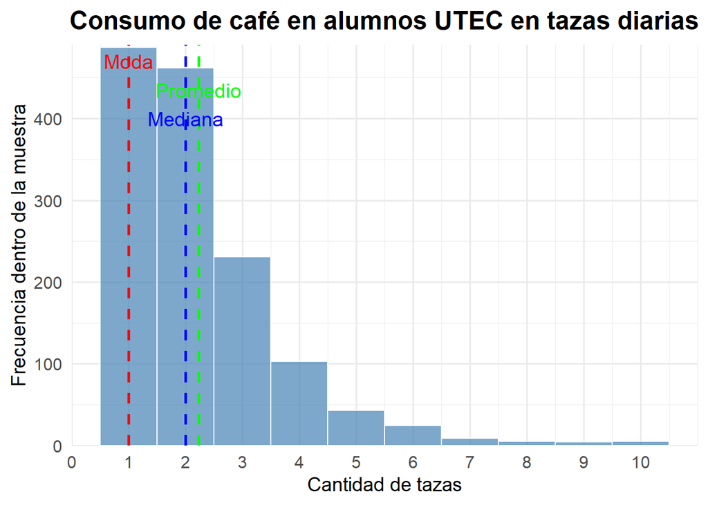

```r
DF2_limpio <- DF2 %>% filter(!is.na(Tazas_por_dia))

moda <- as.numeric(names(sort(table(DF2_limpio$Tazas_por_dia), decreasing = TRUE)[1]))
promedio <- mean(DF2_limpio$Tazas_por_dia, na.rm = TRUE)
mediana <- median(DF2_limpio$Tazas_por_dia, na.rm = TRUE)

grafico_cafe <- ggplot(DF2_limpio, aes(x = Tazas_por_dia)) +
  geom_histogram(binwidth = 1, fill = "steelblue", color = "white", alpha = 0.7) +
  labs(title = "Consumo de café en alumnos UTEC en tazas diarias",
       x = "Cantidad de tazas",
       y = "Frecuencia dentro de la muestra") +
  theme_minimal(base_size = 15) +
  theme(
    plot.title = element_text(hjust = 0.5, face = "bold", size = 18),
    axis.title.x = element_text(size = 14),
    axis.title.y = element_text(size = 14),
    axis.text = element_text(size = 12)
  ) +
  scale_x_continuous(breaks = seq(0, max(DF2_limpio$Tazas_por_dia, na.rm = TRUE), by = 1)) +
  scale_y_continuous(expand = c(0, 0)) +
  geom_vline(aes(xintercept = moda), color = "red", linetype = "dashed", linewidth = 1) +
  geom_vline(aes(xintercept = promedio), color = "green", linetype = "dashed", linewidth = 1) +
  geom_vline(aes(xintercept = mediana), color = "blue", linetype = "dashed", linewidth = 1) +
  annotate("text", x = moda, y = max(table(DF2_limpio$Tazas_por_dia, useNA = "ifany")) + 1, label = "Moda", color = "red", vjust = +1.5, size = 5) +
  annotate("text", x = promedio, y = max(table(DF2_limpio$Tazas_por_dia, useNA = "ifany")) + 2, label = "Promedio", color = "green", vjust = +3.5, size = 5) +
  annotate("text", x = mediana, y = max(table(DF2_limpio$Tazas_por_dia, useNA = "ifany")) + 3, label = "Mediana", color = "blue", vjust = +5.5, size = 5)

print(grafico_cafe)
```

```r
cuantiles <- quantile(DF2$Tazas_por_dia, na.rm = TRUE)
frecuencia_tazas <- table(DF2$Tazas_por_dia)
tazas_no_na <- sum(!is.na(DF2$Tazas_por_dia))
tazas_na <- sum(is.na(DF2$Tazas_por_dia))
consumo_alto <- round(9 / 1373 * 100, 2)
promedio <- round(mean(DF2$Tazas_por_dia, na.rm = TRUE), 2)
cv <- round(sd(DF2$Tazas_por_dia, na.rm = TRUE) / mean(DF2$Tazas_por_dia, na.rm = TRUE) * 100, 2)

cat(
  "Cuantiles del consumo de café (tazas por día):\n", cuantiles, "\n",
  "Frecuencia de tazas por día:\n", frecuencia_tazas, "\n",
  "Total de observaciones (sin NA):", tazas_no_na, "\n",
  "Porcentaje de personas que consumen 9 o más tazas diarias:", consumo_alto, "%\n",
  "Promedio de tazas por día:", promedio, "\n",
  "Coeficiente de variación (CV):", cv, "%\n"
)
```

```
Cuantiles del consumo de café (tazas por día):
 1 1 2 3 10
 Frecuencia de tazas por día:
 487 462 231 103 43 24 9 5 4 5
 Total de observaciones (sin NA): 1373
 Porcentaje de personas que consumen 9 o más tazas diarias: 0.66 %
 Promedio de tazas por día: 2.23
 Coeficiente de variación (CV): 63.42 %
```

### 2. Análisis Rendimiento_con_café

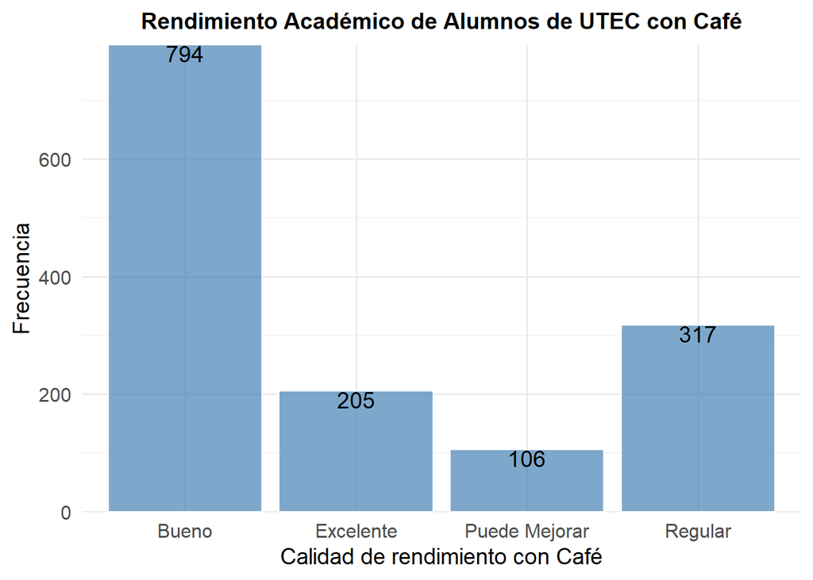

```r
DF2_sin_NA <- DF2 %>% filter(!is.na(Rendimiento_con_cafe))

grafico_rendimiento_cafe <- ggplot(DF2_sin_NA, aes(x = Rendimiento_con_cafe)) +
  geom_bar(fill = "steelblue", color = "white", alpha = 0.7) +
  labs(title = "Rendimiento Académico de Alumnos de UTEC con Café",
       x = "Calidad de rendimiento con Café",
       y = "Frecuencia") +
  theme_minimal(base_size = 15) +
  theme(
    plot.title = element_text(hjust = 0.5, face = "bold", size = 14),
    axis.title.x = element_text(size = 14),
    axis.title.y = element_text(size = 14),
    axis.text = element_text(size = 12)
  ) +
  scale_x_discrete(drop = FALSE) +
  scale_y_continuous(expand = c(0, 0)) +
  geom_text(stat = 'count', aes(label = after_stat(count)), vjust = +1, size = 5)

print(grafico_rendimiento_cafe)
```

```r
total_alumnos <- 794 + 205 + 106 + 317
porcentaje_bueno <- round(794 / total_alumnos * 100, 2)
porcentaje_excelente <- round(205 / total_alumnos * 100, 2)
porcentaje_puede_mejorar <- round(106 / total_alumnos * 100, 2)
porcentaje_regular <- round(317 / total_alumnos * 100, 2)

cat(
  "Distribución del rendimiento académico de los alumnos de UTEC que consumen café:\n",
  "\"Excelente\":", 205, "(", porcentaje_excelente, "%)\n",
  "\"Bueno\":", 794, "(", porcentaje_bueno, "%)\n",
  "\"Regular\":", 317, "(", porcentaje_regular, "%)\n",
  "\"Puede mejorar\":", 106, "(", porcentaje_puede_mejorar, "%)\n"
)
```

```
Distribución del rendimiento académico de los alumnos de UTEC que consumen café:
 "Excelente": 205 ( 14.42 %)
 "Bueno": 794 ( 55.84 %)
 "Regular": 317 ( 22.29 %)
 "Puede mejorar": 106 ( 7.45 %)
```

**Análisis:**

En el gráfico que representa el **rendimiento académico** de los alumnos de UTEC que consumen café, se observa una distribución diferenciada de las categorías, ordenadas de mejor a menor rendimiento: “Excelente” (205), “Bueno” (794), “Regular” (317) y “Puede mejorar” (106). Esta distribución muestra que la mayoría de estudiantes perciben un rendimiento “Bueno” al consumir café, siendo la moda (55.84%). “Regular” ocupa el segundo lugar (22.29%), seguido por “Excelente” (14.42%) y, por último, “Puede mejorar”(7.45%). En base a esta información, podemos concluir que el consumo de café se asocia predominantemente con un buen rendimiento entre los estudiantes de UTEC, con una cantidad significativa que considera su rendimiento como excelente.

### 3. Análisis Promedio_ponderado_2024_1

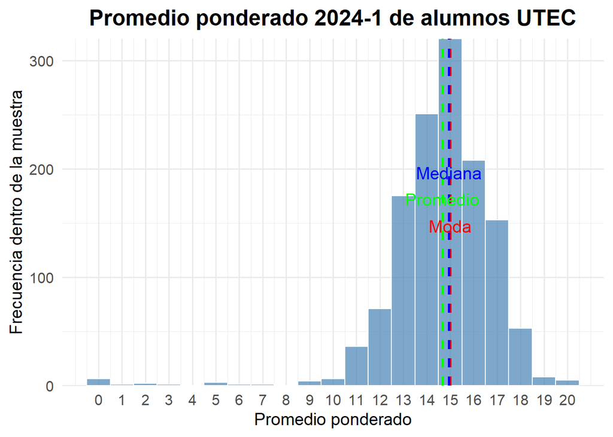

```r
DF2_limpio <- DF2 %>% filter(!is.na(Promedio_ponderado_2024_1))

moda <- as.numeric(names(sort(table(DF2_limpio$Promedio_ponderado_2024_1), decreasing = TRUE)[1]))
promedio <- mean(DF2_limpio$Promedio_ponderado_2024_1, na.rm = TRUE)
mediana <- median(DF2_limpio$Promedio_ponderado_2024_1, na.rm = TRUE)

grafico_promedio <- ggplot(DF2_limpio, aes(x = Promedio_ponderado_2024_1)) +
  geom_histogram(binwidth = 1, fill = "steelblue", color = "white", alpha = 0.7) +
  labs(title = "Promedio ponderado 2024-1 de alumnos UTEC",
       x = "Promedio ponderado",
       y = "Frecuencia dentro de la muestra") +
  theme_minimal(base_size = 15) +
  theme(
    plot.title = element_text(hjust = 0.5, face = "bold", size = 18),
    axis.title.x = element_text(size = 14),
    axis.title.y = element_text(size = 14),
    axis.text = element_text(size = 12)
  ) +
  scale_x_continuous(breaks = seq(0, max(DF2_limpio$Promedio_ponderado_2024_1, na.rm = TRUE), by = 1)) +
  scale_y_continuous(expand = c(0, 0)) +
  geom_vline(aes(xintercept = moda), color = "red", linetype = "dashed", linewidth = 1) +
  geom_vline(aes(xintercept = promedio), color = "green", linetype = "dashed", linewidth = 1) +
  geom_vline(aes(xintercept = mediana), color = "blue", linetype = "dashed", linewidth = 1) +
  annotate("text", x = moda, y = max(table(DF2_limpio$Promedio_ponderado_2024_1, useNA = "ifany")) + 1, label = "Moda", color = "red", vjust = -1.5, size = 5) +
  annotate("text", x = promedio, y = max(table(DF2_limpio$Promedio_ponderado_2024_1, useNA = "ifany")) + 2, label = "Promedio", color = "green", vjust = -3.5, size = 5) +
  annotate("text", x = mediana, y = max(table(DF2_limpio$Promedio_ponderado_2024_1, useNA = "ifany")) + 3, label = "Mediana", color = "blue", vjust = -5.5, size = 5)



print(grafico_promedio)
```

```r
moda_freq <- max(table(DF2$Promedio_ponderado_2024_1))
moda_val <- as.numeric(names(which.max(table(DF2$Promedio_ponderado_2024_1))))
observaciones_no_na <- sum(!is.na(DF2$Promedio_ponderado_2024_1))
observaciones_na <- sum(is.na(DF2$Promedio_ponderado_2024_1))
alumnos_bajo_10 <- sum(DF2$Promedio_ponderado_2024_1 < 10, na.rm = TRUE)
porcentaje_bajo_10 <- round(19 / 1305 * 100, 2)
promedio <- round(mean(DF2$Promedio_ponderado_2024_1, na.rm = TRUE), 2)
mediana <- round(median(DF2$Promedio_ponderado_2024_1, na.rm = TRUE), 2)
coef_var <- round(sd(DF2$Promedio_ponderado_2024_1, na.rm = TRUE) / mean(DF2$Promedio_ponderado_2024_1, na.rm = TRUE) * 100, 2)
porcentaje_moda <- round(123 / 1305 * 100, 2)
alumnos_cerca_mediana <- sum(DF2$Promedio_ponderado_2024_1 >= (median(DF2$Promedio_ponderado_2024_1, na.rm = TRUE) - 2) & DF2$Promedio_ponderado_2024_1 <= (median(DF2$Promedio_ponderado_2024_1, na.rm = TRUE) + 2), na.rm = TRUE)
porcentaje_cerca_mediana <- round(992 / 1305 * 100, 2)

cat(
  "Frecuencia de la moda (15):", moda_freq, "\n",
  "moda:", moda_val, "\n",
  "Total de observaciones (sin NA):", observaciones_no_na, "\n",
  "Número de alumnos con promedio menor a 10:", alumnos_bajo_10, "\n",
  "Porcentaje de alumnos con promedio menor a 10:", porcentaje_bajo_10, "%\n",
  "Promedio:", promedio, "\n",
  "Mediana:", mediana, "\n",
  "Coeficiente de variación:", coef_var, "%\n",
  "Porcentaje de la moda (15):", porcentaje_moda, "%\n",
  "Número de alumnos con promedio dentro del rango ±2 de la mediana:", alumnos_cerca_mediana, "\n",
  "Porcentaje de alumnos con promedio dentro del rango ±2 de la mediana:", porcentaje_cerca_mediana, "%\n"
)
```

```
Frecuencia de la moda (15): 123
 moda: 15
 Total de observaciones (sin NA): 1305
 Número de alumnos con promedio menor a 10: 19
 Porcentaje de alumnos con promedio menor a 10: 1.46 %
 Promedio: 14.68
 Mediana: 14.95
 Coeficiente de variación: 14.89 %
 Porcentaje de la moda (15): 9.43 %
 Número de alumnos con promedio dentro del rango ±2 de la mediana: 992
 Porcentaje de alumnos con promedio dentro del rango ±2 de la mediana: 76.02 %
```

**Análisis:**

Como podemos ver en el presente gráfico, este es asimétrico hacia la izquierda, con más del 98% de los alumnos con un promedio mayor o igual a 10 (solo el 1.46% tiene menos de 10). Sin embargo, si restringimos el dominio a la mitad y nos enfocamos en la parte mayor a 10, notamos que en ese segmento la gráfica es relativamente simétrica, ya que la mediana, la moda y el promedio están muy cerca. La moda es 15, lo que representa el 9.43% de la muestra, mientras que el promedio y la mediana son 14.68 y 14.95, respectivamente. La variable se encuentra muy concentrada alrededor de la mediana, con el 76.02% de los datos en el rango de -2 a +2 a partir de la mediana. Debido a esto, el coeficiente de variación también es bajo (14.89%), por lo que el promedio es el mejor descriptor. La gran mayoría de los alumnos tiene un promedio de entre 13 y 17, lo que se encuentra dentro de lo esperado.

**Variables objetivo 2:**

**Apoyo_económico** => **cualitativa nominal** => **Gráfico de barras**

**Gasto_semanal_café** => **numérica continua** => **histograma**

**Lugar_compra_café** =>**cualitativa nominal** => **Gráfico de barras**

### 4. Análisis Apoyo_económico

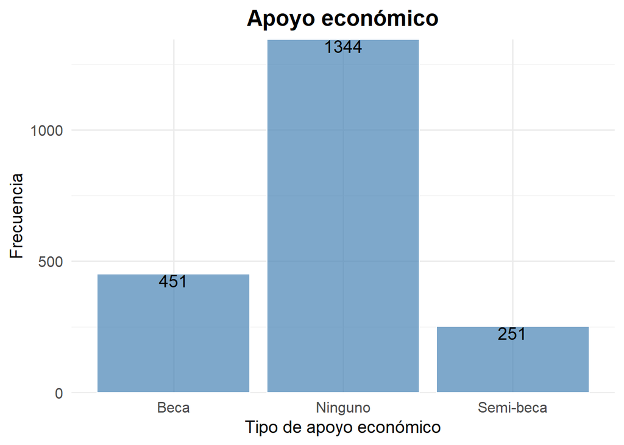

```r
DF2_sin_NA <- DF2 %>% filter(!is.na(Apoyo_economico))

grafico_apoyo_economico <- ggplot(DF2_sin_NA, aes(x = Apoyo_economico)) +
  geom_bar(fill = "steelblue", color = "white", alpha = 0.7) +
  labs(title = "Apoyo económico",
       x = "Tipo de apoyo económico",
       y = "Frecuencia") +
  theme_minimal(base_size = 15) +
  theme(
    plot.title = element_text(hjust = 0.5, face = "bold", size = 18),
    axis.title.x = element_text(size = 14),
    axis.title.y = element_text(size = 14),
    axis.text = element_text(size = 12)
  ) +
  scale_x_discrete(drop = FALSE) +
  scale_y_continuous(expand = c(0, 0)) +
  geom_text(stat = 'count', aes(label = ..count..), vjust = +1, size = 5)

print(grafico_apoyo_economico)
```

```r
cat(
  "porcentaje de estudiantes que no reciben apoyo económico:", round(1344/2046 * 100, 2), "%\n",
  "porcentaje de estudiantes con beca:", round(451/2046 * 100, 2), "%\n",
  "porcentaje de estudiantes con semi-beca:", round(251/2046 * 100, 2), "%\n"
)
```

```
porcentaje de estudiantes que no reciben apoyo económico: 65.69 %
 porcentaje de estudiantes con beca: 22.04 %
 porcentaje de estudiantes con semi-beca: 12.27 %
```

**Análisis**:

En este gráfico, que representa el *tipo de ayuda económica* de los alumnos de UTEC, se observa una clara diferenciación en las categorías de ayuda económica, ordenadas de mayor a menor frecuencia: “Ninguno” (1344), “Beca” (451), “Semi-beca” (251). Esta distribución muestra que la mayoría de los estudiantes no reciben ningún apoyo económico (65.69%). La opción “Beca” ocupa el segundo lugar (22.04%), seguida finalmente por “Semi-beca” (12.27%). La moda indica que la mayoría de los estudiantes entrevistados que consumen café no poseen ningún tipo de beca académica en la UTEC.

### 5. Análisis Gasto_semanal_café

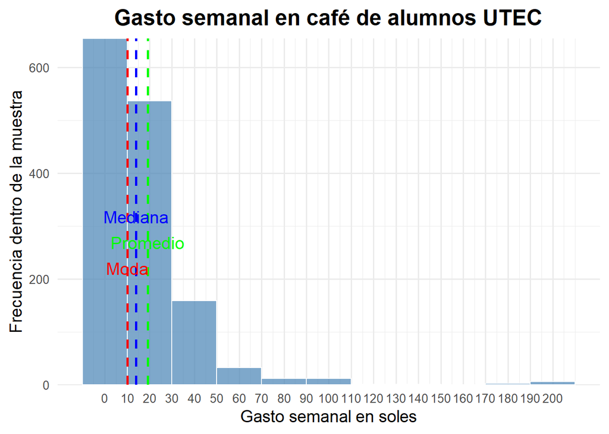

```r
DF2_limpio <- DF2 %>% filter(!is.na(Gasto_semanal_cafe))

moda <- as.numeric(names(sort(table(DF2_limpio$Gasto_semanal_cafe), decreasing = TRUE)[1]))
promedio <- mean(DF2_limpio$Gasto_semanal_cafe, na.rm = TRUE)
mediana <- median(DF2_limpio$Gasto_semanal_cafe, na.rm = TRUE)

grafico_cafe <- ggplot(DF2_limpio, aes(x = Gasto_semanal_cafe)) +
  geom_histogram(binwidth = 20, fill = "steelblue", color = "white", alpha = 0.7) +
  labs(title = "Gasto semanal en café de alumnos UTEC",
       x = "Gasto semanal en soles",
       y = "Frecuencia dentro de la muestra") +
  theme_minimal(base_size = 15) +
  theme(
    plot.title = element_text(hjust = 0.5, face = "bold", size = 18),
    axis.title.x = element_text(size = 14),
    axis.title.y = element_text(size = 14),
    axis.text = element_text(size = 10)
  ) +
  scale_x_continuous(breaks = seq(0, max(DF2_limpio$Gasto_semanal_cafe, na.rm = TRUE), by = 10)) +
  scale_y_continuous(expand = c(0, 0)) +
  geom_vline(aes(xintercept = moda), color = "red", linetype = "dashed", linewidth = 1) +
  geom_vline(aes(xintercept = promedio), color = "green", linetype = "dashed", linewidth = 1) +
  geom_vline(aes(xintercept = mediana), color = "blue", linetype = "dashed", linewidth = 1) +
  annotate("text", x = moda, y = max(table(DF2_limpio$Gasto_semanal_cafe, useNA = "ifany")) + 1, label = "Moda", color = "red", vjust = -1.5, size = 5) +
  annotate("text", x = promedio, y = max(table(DF2_limpio$Gasto_semanal_cafe, useNA = "ifany")) + 2, label = "Promedio", color = "green", vjust = -3.5, size = 5) +
  annotate("text", x = mediana, y = max(table(DF2_limpio$Gasto_semanal_cafe, useNA = "ifany")) + 3, label = "Mediana", color = "blue", vjust = -5.5, size = 5)

print(grafico_cafe)
```

```r
n_total <- sum(!is.na(DF2$Promedio_ponderado_2024_1))
promedio <- mean(DF2$Gasto_semanal_cafe, na.rm = TRUE)
mediana <- median(DF2$Gasto_semanal_cafe, na.rm = TRUE)
moda <- as.numeric(names(sort(table(DF2$Gasto_semanal_cafe), decreasing = TRUE)[1]))
cv <- round((sd(DF2$Gasto_semanal_cafe, na.rm = TRUE) / mean(DF2$Gasto_semanal_cafe, na.rm = TRUE)) * 100, 2)
n_gasto_40 <- nrow(filter(DF2, Gasto_semanal_cafe >= 40))
porcentaje_gasto_40 <- round((n_gasto_40 / n_total) * 100, 2)

cat(
  "promedio:", round(promedio, 2), "\n",
  "mediana:", mediana, "\n",
  "total:", n_total, "\n",
  "moda:", moda, "\n",
  "coeficiente de variación:", cv, "%\n",
  "número de alumnos que gastan más de 40 soles:", n_gasto_40, "\n",
  "porcentaje de alumnos que gastan más de 40 soles:", porcentaje_gasto_40, "%\n"
)
```

```
promedio: 19.29
 mediana: 14
 total: 1305
 moda: 10
 coeficiente de variación: 115.95 %
 número de alumnos que gastan más de 40 soles: 201
 porcentaje de alumnos que gastan más de 40 soles: 15.4 %
```

### 6. Análisis Lugar_compra_café

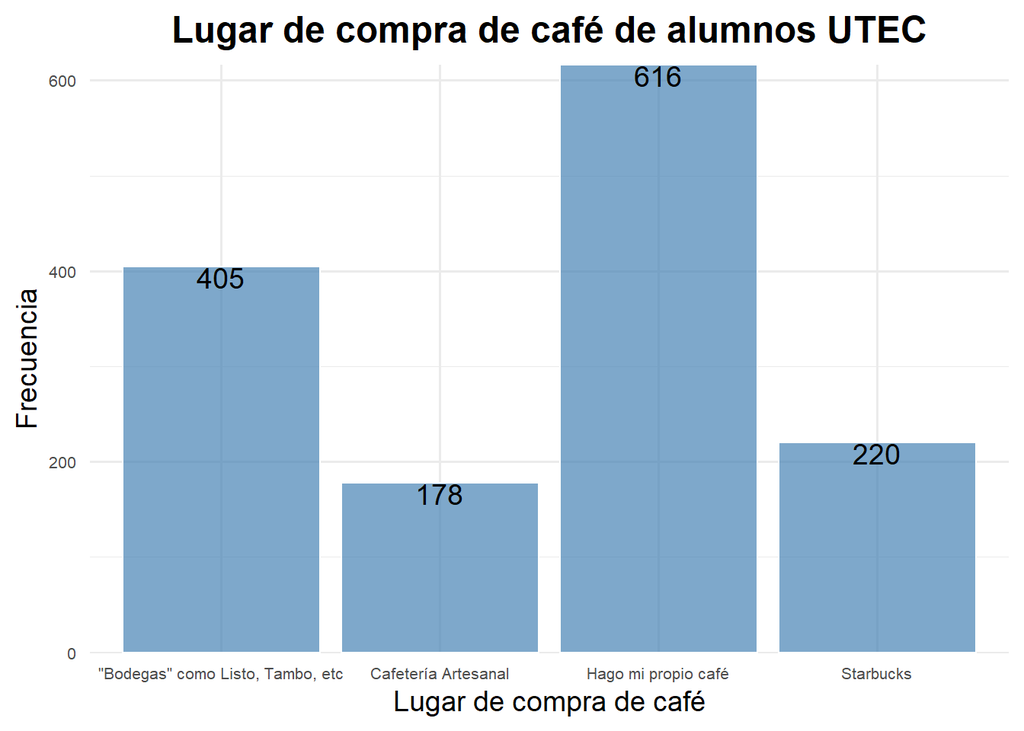

```r
DF2_sin_NA <- DF2 %>% filter(!is.na(Lugar_compra_cafe))

grafico_lugar_compra_cafe <- ggplot(DF2_sin_NA, aes(x = Lugar_compra_cafe)) +
  geom_bar(fill = "steelblue", color = "white", alpha = 0.7) +
  labs(title = "Lugar de compra de café de alumnos UTEC",
       x = "Lugar de compra de café",
       y = "Frecuencia") +
  theme_minimal(base_size = 15) +
  theme(
    plot.title = element_text(hjust = 0.5, face = "bold", size = 18),
    axis.title.x = element_text(size = 14),
    axis.title.y = element_text(size = 14),
    axis.text = element_text(size = 8)
  ) +
  scale_x_discrete(drop = FALSE) +
  scale_y_continuous(expand = c(0, 0)) +
  geom_text(stat = 'count', aes(label = ..count..), vjust = +1, size = 5)

print(grafico_lugar_compra_cafe)
```

```r
total_lugar_compra <- sum(!is.na(DF2$Lugar_compra_cafe))
lugares <- table(DF2_sin_NA$Lugar_compra_cafe)

for (lugar in names(lugares)) {
  porcentaje <- round(lugares[lugar] / total_lugar_compra * 100, 2)
  print(paste("El porcentaje de estudiantes que compran en", lugar, "es:", porcentaje))
}
```

```
[1] "El porcentaje de estudiantes que compran en \"Bodegas\" como Listo, Tambo, etc es: 28.54"
[1] "El porcentaje de estudiantes que compran en Cafetería Artesanal es: 12.54"
[1] "El porcentaje de estudiantes que compran en Hago mi propio café es: 43.41"
[1] "El porcentaje de estudiantes que compran en Starbucks es: 15.5"
```

**Análisis**:

El gráfico de la variable “Lugar_compra_café” revela diferencias significativas en los establecimientos donde los estudiantes adquieren su café. La opción más popular es “Hago mi propio café” con 616 respuestas, lo que representa el 43.41% de la muestra. Sin embargo, más de la mitad de los estudiantes (56.59%) optan por comprar café en otros lugares; dentro de este grupo, el 28.54% compra su café en bodegas como Listo y Tambo, mientras que un 15.5% lo hace en Starbucks, lo cual resulta sorprendente dado el alto costo de sus productos. Las cafeterías artesanales ocupan el último lugar con un 12.54%, probablemente debido a su menor disponibilidad y reconocimiento en comparación con las otras opciones. Los resultados indican que la mayoría de los alumnos de UTEC prefieren comprar su café, reflejando una tendencia hacia la practicad.

## 2. Análisis de interacción

Una vez analizadas las variables, el siguiente paso es explorar su relación. En el objetivo 1, buscamos determinar si hay relación entre la cantidad de café que consume un alumno y su rendimiento académico, utilizando las variables de café consumido, rendimiento académico y promedio ponderado. Filtraremos a los alumnos en dos grupos: los que consumen de 1 a 2 tazas y los que consumen 3 o más, y crearemos un gráfico con “facet wrap” para visualizar los rendimientos, esperando que el grupo de mayor consumo tenga una mayor proporción de rendimientos “Excelente” y “Bueno”.

Para el objetivo 2, nuestra hipótesis se centra en la relación entre el estatus económico del alumno (a través del apoyo económico) y su gasto en café y lugar de compra. Se plantea que los alumnos con menos dificultades económicas gastarán más en café y preferirán comprarlo en lugares exclusivos. Formaremos dos grupos basados en el apoyo económico: no becados y becados, analizando su gasto semanal y los lugares de compra, anticipando que los no becados tendrán un mayor gasto y preferirán comprar café en lugar de prepararlo en casa.

### Análisis objetivo 1:

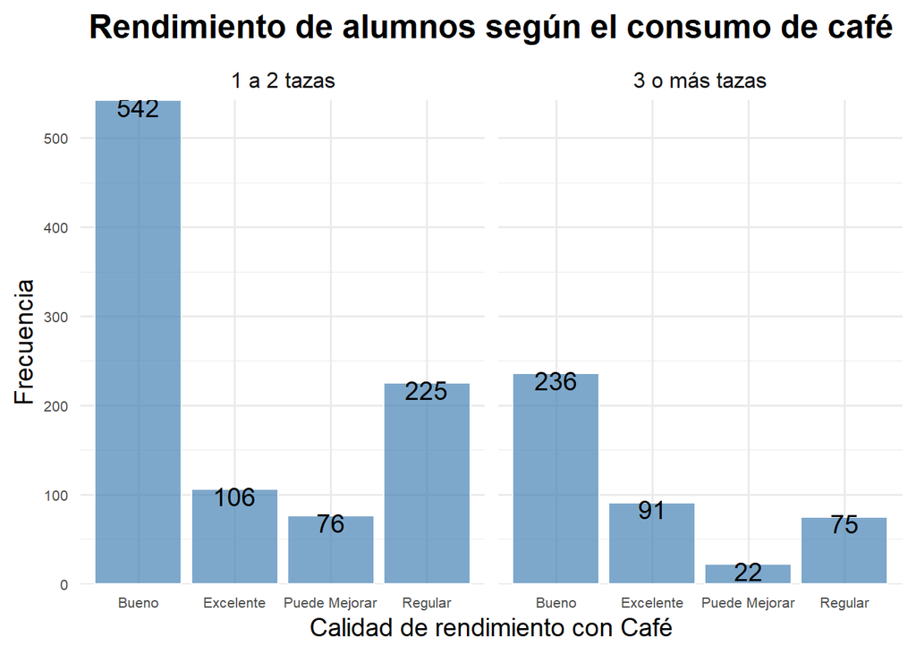

```r
DF2 <- DF2 %>%
  mutate(Tazas_categoria = case_when(
    Tazas_por_dia >= 1 & Tazas_por_dia <= 2 ~ "1 a 2 tazas",
    Tazas_por_dia >= 3 ~ "3 o más tazas",
    TRUE ~ NA_character_
  ))

DF2_filtrado <- DF2 %>%
  filter(!is.na(Tazas_categoria))

grafico_rendimiento_cafe <- DF2_filtrado %>%
  ggplot(aes(x = Rendimiento_con_cafe)) +
  geom_bar(fill = "steelblue", color = "white", alpha = 0.7) +
  labs(title = "Rendimiento de alumnos según el consumo de café",
       x = "Calidad de rendimiento con Café",
       y = "Frecuencia") +
  theme_minimal(base_size = 15) +
  theme(
    plot.title = element_text(hjust = 0.5, face = "bold", size = 18),
    axis.title.x = element_text(size = 14),
    axis.title.y = element_text(size = 14),
    axis.text = element_text(size = 8)
  ) +
  scale_x_discrete(drop = FALSE) +
  scale_y_continuous(expand = c(0, 0)) +
  geom_text(stat = 'count', aes(label = ..count..), vjust = +0.85, size = 5) +
  facet_wrap(~ Tazas_categoria)
print(grafico_rendimiento_cafe)
```

```r
porcentaje_bueno_1_2_tazas <- round(542 / 949 * 100, 2)
porcentaje_excelente_1_2_tazas <- round(106 / 949 * 100, 2)
porcentaje_regular_1_2_tazas <- round(225 / 949 * 100, 2)
porcentaje_bueno_3_mas_tazas <- round(236 / 424 * 100, 2)
porcentaje_excelente_3_mas_tazas <- round(91 / 424 * 100, 2)
porcentaje_regular_3_mas_tazas <- round(75 / 424 * 100, 2)

cat(
  "Porcentaje de rendimiento \"bueno\" en el grupo de 1 a 2 tazas:", porcentaje_bueno_1_2_tazas, "%\n",
  "Porcentaje de rendimiento \"excelente\" en el grupo de 1 a 2 tazas:", porcentaje_excelente_1_2_tazas, "%\n",
  "Porcentaje de rendimiento \"regular\" en el grupo de 1 a 2 tazas:", porcentaje_regular_1_2_tazas, "%\n",
  "Porcentaje de rendimiento \"bueno\" en el grupo de 3 o más tazas:", porcentaje_bueno_3_mas_tazas, "%\n",
  "Porcentaje de rendimiento \"excelente\" en el grupo de 3 o más tazas:", porcentaje_excelente_3_mas_tazas, "%\n",
  "Porcentaje de rendimiento \"regular\" en el grupo de 3 o más tazas:", porcentaje_regular_3_mas_tazas, "%\n"
)
```

```
Porcentaje de rendimiento "bueno" en el grupo de 1 a 2 tazas: 57.11 %
 Porcentaje de rendimiento "excelente" en el grupo de 1 a 2 tazas: 11.17 %
 Porcentaje de rendimiento "regular" en el grupo de 1 a 2 tazas: 23.71 %
 Porcentaje de rendimiento "bueno" en el grupo de 3 o más tazas: 55.66 %
 Porcentaje de rendimiento "excelente" en el grupo de 3 o más tazas: 21.46 %
 Porcentaje de rendimiento "regular" en el grupo de 3 o más tazas: 17.69 %
```

**Análisis:**

Como podemos ver, el gráfico 1 (grupo de entre 1 y 2 tazas) y el gráfico 2 (grupo de entre 3 o más tazas) son significativamente diferentes. Si bien la moda en ambos es el rendimiento tipo “Bueno” (57.11% en el gráfico 1, 55.66% en el gráfico 2), el porcentaje de alumnos con rendimiento “Excelente” es muchísimo más alto en el gráfico 2, siendo del 21.46%, mientras que el porcentaje de alumnos con rendimiento “Excelente” en el gráfico 1 es apenas del 11.17%. En otras palabras, los alumnos que toman 3 o más tazas de café al día tienen, en proporción al tamaño de su grupo, unas 2 veces más personas con rendimiento excelente en comparación con los alumnos que solo toman de 1 a 2 tazas de café al día. En cuanto al porcentaje de alumnos con rendimiento “Regular”, este es significativamente más bajo en el gráfico 2, siendo solo del 17.69%, mientras que en el gráfico 1 es del 23.71%.

En base a esto, podemos decir que la hipótesis, al menos en el contexto de esta variable, pues hay una cierta relación directamente proporcional entre mayor consumo de café y mejor rendimiento académico, al menos el percibido.

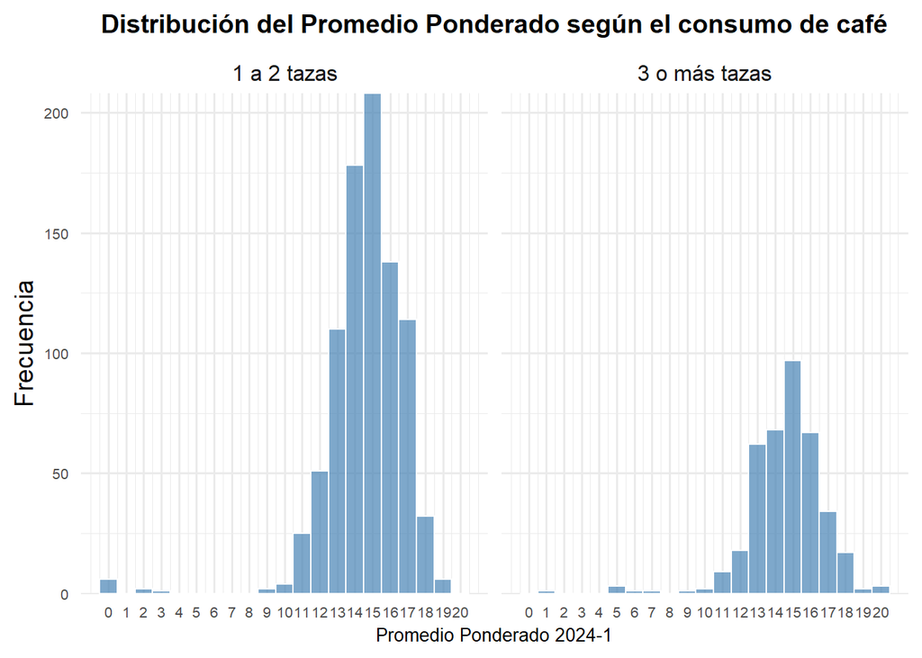

```r
DF2_filtrado <- DF2 %>%
  filter(!is.na(Tazas_categoria) & !is.na(Promedio_ponderado_2024_1))

grafico_promedio <- DF2_filtrado %>%
  ggplot(aes(x = Promedio_ponderado_2024_1)) +
  geom_histogram(binwidth = 1, fill = "steelblue", color = "white", alpha = 0.7) +
  labs(title = "Distribución del Promedio Ponderado según el consumo de café",
       x = "Promedio Ponderado 2024-1",
       y = "Frecuencia") +
  theme_minimal(base_size = 15) +
  theme(
    plot.title = element_text(hjust = 0.5, face = "bold", size = 14),
    axis.title.x = element_text(size = 10),
    axis.title.y = element_text(size = 14),
    axis.text = element_text(size = 8)
  ) +
  scale_x_continuous(breaks = seq(0, max(DF2_filtrado$Promedio_ponderado_2024_1, na.rm = TRUE), by = 1)) +
  scale_y_continuous(expand = c(0, 0)) +
  facet_wrap(~ Tazas_categoria)

print(grafico_promedio)
```

```r
grupo_1_2 <- DF2 %>% filter(Tazas_por_dia >= 1 & Tazas_por_dia <= 2)
grupo_3_mas <- DF2 %>% filter(Tazas_por_dia >= 3)

mediana_1_2 <- median(grupo_1_2$Promedio_ponderado_2024_1, na.rm = TRUE)
promedio_1_2 <- mean(grupo_1_2$Promedio_ponderado_2024_1, na.rm = TRUE)
cuantiles_1_2 <- quantile(grupo_1_2$Promedio_ponderado_2024_1, na.rm = TRUE)

mediana_3_mas <- median(grupo_3_mas$Promedio_ponderado_2024_1, na.rm = TRUE)
promedio_3_mas <- mean(grupo_3_mas$Promedio_ponderado_2024_1, na.rm = TRUE)
cuantiles_3_mas <- quantile(grupo_3_mas$Promedio_ponderado_2024_1, na.rm = TRUE)

correlacion <- cor(DF2$Promedio_ponderado_2024_1, DF2$Tazas_por_dia, use = "complete.obs")

cat(
  "Grupo 1-2 Tazas:\n",
  "Mediana:", mediana_1_2, "\n",
  "Promedio:", round(promedio_1_2, 2), "\n",
  "Cuantiles:", cuantiles_1_2, "\n\n",
  "Grupo 3 o más Tazas:\n",
  "Mediana:", mediana_3_mas, "\n",
  "Promedio:", round(promedio_3_mas, 2), "\n",
  "Cuantiles:", cuantiles_3_mas, "\n\n",
  "Coeficiente de correlación:", round(correlacion, 5), "\n"
)
```

```
Grupo 1-2 Tazas:
 Mediana: 15
 Promedio: 14.67
 Cuantiles: 0 13.78 15 16 19.3

 Grupo 3 o más Tazas:
 Mediana: 14.88
 Promedio: 14.66
 Cuantiles: 1 13.5 14.88 16 20

 Coeficiente de correlación: 0.00033
```

### Análisis objetivo 2:

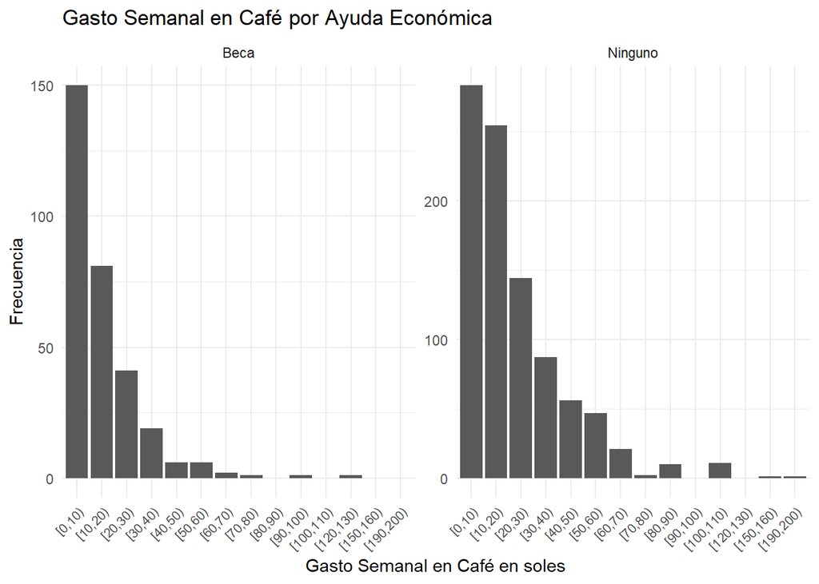

```r
library(ggplot2)
library(dplyr)

datos_filtrados_ninguno <- DF2 %>%
  filter(Apoyo_economico == "Ninguno" & !is.na(Gasto_semanal_cafe)) %>%
  mutate(rango_gasto = cut(Gasto_semanal_cafe, breaks = seq(0, max(Gasto_semanal_cafe, na.rm = TRUE), by = 10), right = FALSE)) %>%
  select(rango_gasto, Apoyo_economico)

datos_filtrados_beca <- DF2 %>%
  filter(Apoyo_economico == "Beca" & !is.na(Gasto_semanal_cafe)) %>%
  mutate(rango_gasto = cut(Gasto_semanal_cafe, breaks = seq(0, max(Gasto_semanal_cafe, na.rm = TRUE), by = 10), right = FALSE)) %>%
  select(rango_gasto, Apoyo_economico)

datos_filtrados <- bind_rows(datos_filtrados_ninguno, datos_filtrados_beca)

frecuencias <- datos_filtrados %>%
  group_by(Apoyo_economico, rango_gasto) %>%
  summarise(frecuencia = n(), .groups = 'drop') %>%
  filter(!is.na(rango_gasto))

ggplot(frecuencias, aes(x = rango_gasto, y = frecuencia)) +
  geom_bar(stat = "identity") +
  labs(x = "Gasto Semanal en Café en soles", y = "Frecuencia", title = "Gasto Semanal en Café por Ayuda Económica") +
  theme_minimal() +
  theme(axis.text.x = element_text(angle = 45, hjust = 1, size = 8)) +
  facet_wrap(~Apoyo_economico, scales = "free_y")
```

```r
calcular_estadisticos <- function(data, grupo) {
  data_grupo <- data %>% filter(Apoyo_economico == grupo & !is.na(Gasto_semanal_cafe))

  moda <- as.numeric(names(sort(table(data_grupo$Gasto_semanal_cafe), decreasing = TRUE)[1]))
  mediana <- median(data_grupo$Gasto_semanal_cafe)
  promedio <- mean(data_grupo$Gasto_semanal_cafe)
  cuantiles <- quantile(data_grupo$Gasto_semanal_cafe, probs = c(0.25, 0.5, 0.75))

  return(list(
    moda = moda,
    mediana = mediana,
    promedio = promedio,
    cuantiles = cuantiles
  ))
}

estadisticos_ninguno <- calcular_estadisticos(DF2, "Ninguno")
estadisticos_beca <- calcular_estadisticos(DF2, "Beca")

cat(
  "Estadísticos del grupo 'Ninguno':\n",
  "  Moda:", estadisticos_ninguno$moda, "\n",
  "  Mediana:", estadisticos_ninguno$mediana, "\n",
  "  Promedio:", round(estadisticos_ninguno$promedio, 2), "\n",
  "  Cuantiles (25%, 50%, 75%):", estadisticos_ninguno$cuantiles, "\n\n",
  "Estadísticos del grupo 'Beca':\n",
  "  Moda:", estadisticos_beca$moda, "\n",
  "  Mediana:", estadisticos_beca$mediana, "\n",
  "  Promedio:", round(estadisticos_beca$promedio, 2), "\n",
  "  Cuantiles (25%, 50%, 75%):", estadisticos_beca$cuantiles, "\n"
)
```

```
Estadísticos del grupo 'Ninguno':
   Moda: 10
   Mediana: 15
   Promedio: 20.88
   Cuantiles (25%, 50%, 75%): 6 15 30

 Estadísticos del grupo 'Beca':
   Moda: 5
   Mediana: 10
   Promedio: 13.55
   Cuantiles (25%, 50%, 75%): 5 10 20
```

**Análisis**:

Los resultados del gasto semanal en café entre los grupos “Ninguno” y “Beca” muestran diferencias notables. En el grupo “Ninguno”, la moda es de 10 soles, con una mediana de 15 soles y un promedio considerablemente más alto de 20.88 soles. Esto sugiere que, aunque la mayoría de los estudiantes gasta alrededor de 10 soles, hay algunos que gastan mucho más, lo que eleva el promedio. Los cuantiles refuerzan esto, con el 25% de los estudiantes gastando hasta 6 soles y el 75% hasta 30 soles. En contraste, el grupo “Beca” tiene una moda más baja de 5 soles, una mediana de 10 soles y un promedio también más bajo de 13.55 soles. Esto indica que los estudiantes con beca tienden a gastar menos en café en promedio. Además, el 50% de los estudiantes becados gasta entre 5 y 20 soles. En resumen, los estudiantes sin apoyo económico tienden a gastar más en café, lo que podría estar relacionado con su capacidad económica.

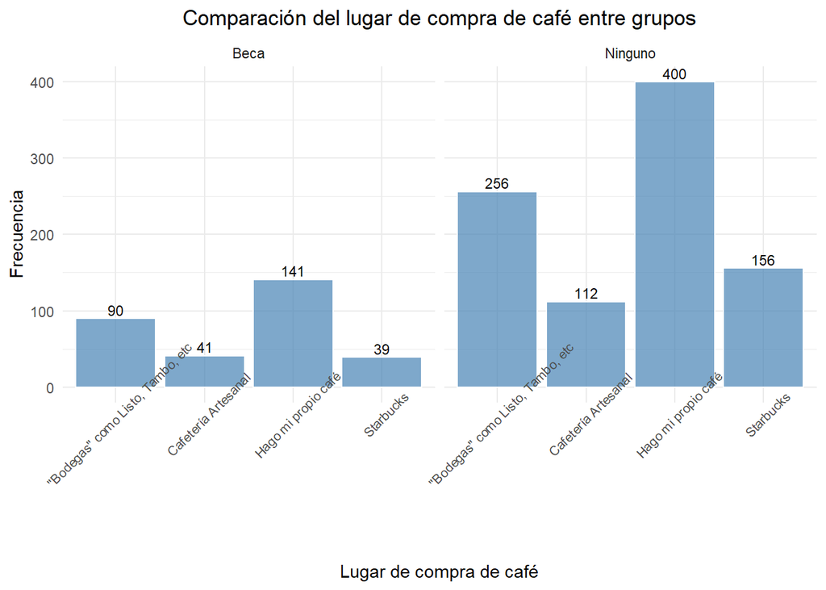

```r
datos_combinados <- DF2 %>%
  filter(Apoyo_economico %in% c("Ninguno", "Beca") & !is.na(Lugar_compra_cafe))

grafico_comb <- ggplot(datos_combinados, aes(x = Lugar_compra_cafe)) +
  geom_bar(fill = "steelblue", color = "white", alpha = 0.7) +
  facet_wrap(~ Apoyo_economico) +
  labs(x = "Lugar de compra de café", y = "Frecuencia", title = "Comparación del lugar de compra de café entre grupos") +
  theme_minimal() +
  theme(
    axis.text.x = element_text(angle = 45, hjust = 0.5, size = 8),
    plot.title = element_text(hjust = 0.5)
  ) +
  geom_text(stat = "count", aes(label = ..count..), vjust = -0.3, size = 3)

print(grafico_comb)
```

```r
porcentaje_propio_cafe_becados <- round(141 / 311 * 100, 2)
porcentaje_propio_cafe_no_becados <- round(400 / 924 * 100, 2)
porcentaje_bodegas_becados <- round(90 / 311 * 100, 2)
porcentaje_bodegas_no_becados <- round(256 / 924 * 100, 2)
porcentaje_starbucks_becados <- round(39 / 311 * 100, 2)
porcentaje_starbucks_no_becados <- round(156 / 924 * 100, 2)
porcentaje_artesanales_becados <- round(41 / 311 * 100, 2)
porcentaje_artesanales_no_becados <- round(112 / 924 * 100, 2)

cat(
  "Porcentaje de estudiantes becados que hacen su propio café:", porcentaje_propio_cafe_becados, "%\n",
  "Porcentaje de estudiantes no becados que hacen su propio café:", porcentaje_propio_cafe_no_becados, "%\n",
  "Porcentaje de estudiantes becados que compran en bodegas:", porcentaje_bodegas_becados, "%\n",
  "Porcentaje de estudiantes no becados que compran en bodegas:", porcentaje_bodegas_no_becados, "%\n",
  "Porcentaje de estudiantes becados que compran en Starbucks:", porcentaje_starbucks_becados, "%\n",
  "Porcentaje de estudiantes no becados que compran en Starbucks:", porcentaje_starbucks_no_becados, "%\n",
  "Porcentaje de estudiantes becados que compran en cafeterías artesanales:", porcentaje_artesanales_becados, "%\n",
  "Porcentaje de estudiantes no becados que compran en cafeterías artesanales:", porcentaje_artesanales_no_becados, "%\n"
)
```

```
Porcentaje de estudiantes becados que hacen su propio café: 45.34 %
 Porcentaje de estudiantes no becados que hacen su propio café: 43.29 %
 Porcentaje de estudiantes becados que compran en bodegas: 28.94 %
 Porcentaje de estudiantes no becados que compran en bodegas: 27.71 %
 Porcentaje de estudiantes becados que compran en Starbucks: 12.54 %
 Porcentaje de estudiantes no becados que compran en Starbucks: 16.88 %
 Porcentaje de estudiantes becados que compran en cafeterías artesanales: 13.18 %
 Porcentaje de estudiantes no becados que compran en cafeterías artesanales: 12.12 %
```

**Análisis**:

Al analizar los resultados de los grupos becados y no becados en relación con dónde compran su café, observamos algunas diferencias interesantes. En ambos grupos, la moda es que los estudiantes prefieren hacer su propio café: el 45.34% en el grupo de becados y el 43.29% en el grupo sin beca, lo que refleja una preferencia similar. Sin embargo, entre los que compran su café, que en ambos grupos son la mayoría, los becados optan más frecuentemente por “Bodegas” (28.94%) en comparación con los no becados (27.71%). Hay una diferencia importante en el consumo de Starbucks, siendo la opción del 16.88% de los no becados frente al 12.54% de los becados. Esto podría reflejar una diferencia en poder adquisitivo. En cuanto a las “Cafeterías artesanales”, ambos grupos muestran porcentajes bajos, siendo ligeramente más común entre los becados (13.18%) que entre los no becados (12.12%). En resumen, los estudiantes sin beca parecen estar en condiciones de gastar más, mientras que los becados, aunque siguen la misma tendencia general: opciones más asequibles.

# IIII. Conclusiones

En nuestra investigación sobre el consumo de café entre los estudiantes de UTEC y su relación con el rendimiento académico y el impacto económico, destacamos que la mayoría de los estudiantes perciben un rendimiento “bueno” al consumir café, aunque no encontramos una correlación significativa entre el consumo de café y las calificaciones reales. Sin embargo, observamos que los estudiantes que consumen más de 3 tazas al día tienden a reportar un mayor rendimiento percibido. Económicamente, los estudiantes sin apoyo financiero gastan más en café, con una mayor inclinación a comprar en lugares más caros, como Starbucks, lo que sugiere diferencias en poder adquisitivo.